# Devoir Maison R

Larry Kiener

08/11/2021

# 3.1 Mise en place

## 3.1.3 Code et types d’activités => commerces alimentaires

- Nombre d’entreprises ayant un nom (enseigne1Etablissement) qui comprend le terme “BOULANGERIE”:

```r
# Decompte des lignes apres filtrage nom contenant boulangerie
nrow(filter(data42,str_detect(enseigne1Etablissement,"BOULANGERIE")))
```

```
## [1] 84
```

- Ajoutez une variable Code à votre table en ne conservant que les quatre premiers caractères de la variable activitePrincipaleEtablissement

```r
# Ajout des caracteres 1 à 4
data42$code = substring(data42$activitePrincipaleEtablissement , 1, 4)
# vérification head(data42$code)
```

- Filtrez les lignes de data42 pour ne retenir que celles pour lesquelles l’APE correspond aux commerces “alimentaires” -alimentation, boisson, restaurant, bar

```r
# nb lignes avant filtrage
nrow(data42)
```

```
## [1] 303290
```

```r
# utilisation de %in% pour comparer chaque code à la liste de code de APE_Type
alim42=filter(data42, data42$code %in% APE_Type$Code)
# verification du nb lignes après filtrage
nrow(alim42)
```

```
## [1] 12871
```

- Stockez le résultat de ces opérations dans un objet alim42 (+conversion de la variable “code”)

```r
# conversion
alim42$code=as.double(alim42$code)

# verification de la converion
typeof(alim42$code)
```

```
## [1] "double"
```

- Réalisez une jointure entre data42_alim (variable codeAPE) et APE_Type (variable Code), de manière à compléter alim42 avec les types de commerces

```r
dim(alim42)
```

```
## [1] 12871    58
```

```r
# jointure
alim42=left_join(alim42,APE_Type,by = c("code" = "Code"))

# verification de l'ajout des colonnes de APE_type
dim(alim42)
```

```
## [1] 12871    60
```

## 3.1.4 Résumé, classement

- Quelles sont les 3 communes de votre base de données qui comptent le plus de magasins alimentaires?

```r
head(arrange(summarise(group_by(alim42,libelleCommuneEtablissement),nb_com_alimentaire=n()),desc(nb_com_alimentaire)),3)
```

```
## # A tibble: 3 x 2
##   libelleCommuneEtablissement nb_com_alimentaire
##   <chr>                                    <int>
## 1 SAINT ETIENNE                             3819
## 2 ROANNE                                     919
## 3 SAINT CHAMOND                              536
```

- Pour les communes qui ne comptent qu’un seul commerce “alimentaire”, de quel type est-il, le plus fréquemment?

```r
#regroupement par commun et decompte des commerces alimentaires
commerce_alim_unique=summarise(group_by(alim42,libelleCommuneEtablissement),nb_com_alimentaire=n())

#ne retnir que les communes avec 1 seul commerce alimentaire
commerce_alim_unique= filter(commerce_alim_unique,nb_com_alimentaire==1)

# Dans ces communes, ajout du type de commerce
commerce_alim_unique=left_join(commerce_alim_unique,select(alim42,libelleCommuneEtablissement, TypeAbreg))
type_le_plus_freq=summarise(group_by(commerce_alim_unique,TypeAbreg),freq_alim_uniq=n())
#classement
head(arrange(type_le_plus_freq,desc(freq_alim_uniq)),1)
```

```
## # A tibble: 1 x 2
##   TypeAbreg freq_alim_uniq
##   <chr>              <int>
## 1 restau                 5
```

- Quelles communes de plus de 100 commerces comptent au moins 10 commerces de type “viande”?

```r
# regroupement par commune et compte du nombre de commerces alimentaires
com_plus_de_100=summarise(group_by(alim42,libelleCommuneEtablissement),nb_com_alimentaire=n())

# que les communes avec plus de 100 commerces
com_plus_de_100= filter(com_plus_de_100,nb_com_alimentaire>100)

# Parmi les villes de plus de 100 commerce, on rattache les commerces de viande
com_10_viande=left_join(com_plus_de_100,select(filter(alim42,TypeAbreg=="viande"),libelleCommuneEtablissement, TypeAbreg))

#Decompte du nombre de commerces de viande
com_10_viande=summarise(group_by(com_10_viande,libelleCommuneEtablissement),nb_com_viande=n())

#Filtre des communes qui ont plus de 10 commerces de viande
com_10_viande= filter(com_10_viande,nb_com_viande>=10)

#classement
print(arrange(com_10_viande,desc(nb_com_viande)))
```

```
## # A tibble: 5 x 2
##   libelleCommuneEtablissement nb_com_viande
##   <chr>                               <int>
## 1 SAINT ETIENNE                          24
## 2 MONTBRISON                             19
## 3 FEURS                                  13
## 4 ROANNE                                 13
## 5 LA TALAUDIERE                          12
```

# 3.2 Rapport, statistiques descriptives

- Rédigez un petit paragraphe pour nommer les 3 communes qui comptent le plus d’entreprises (exercice précédent) en utilisant l’insertion d’“inline chunks”.

```r
#Decompte du nobre d'entreprises
com_nb_entr=summarise(group_by(data42,libelleCommuneEtablissement),nb_entreprise=n())

#classement
com_nb_entr=head(arrange(com_nb_entr,desc(nb_entreprise)),3)
```

Les communes qui comptent le plus d’entreprises sont :  
1. SAINT ETIENNE  
2.ROANNE  
3. SAINT CHAMOND

# 3.3 Programmation: automatisation pour plusieurs départements

## 3.3.1 Fonction

Réutilisez les commandes que vous avez mises au point sur data42 pour écrire une fonction get_clean_data() qui réalisera l’ensemble de ces opérations sur le département de votre choix. L’input correspondra à un numéro de département (c’est-à-dire que vous pourrez utiliser la fonction en faisant, par exemple get_clean_data(“01”)).

```r
get_clean_data  <-function(num_departement){

  APE_Type=read.csv("data/APE_Type.csv")

  # Vérification de l'existence de données pour le numéro de département passé en argument
  if (!file.exists(paste("data/geo_siret_",num_departement,".csv",sep = "", collapse = NULL))){
    message("No data available, try another departement number")
    }
  else{
    #Lecture du csv avec le bon numero de departement
    data_departement=read.csv(paste("data/geo_siret_",num_departement,".csv",sep = "", collapse = NULL))

    # modification du code pour avoir une correspondance avec la base APE_Type
    data_departement$code = substring(data_departement$activitePrincipaleEtablissement , 1, 4)

    # Recupération des données concernant l'alimentation
    alim_departement=filter(data_departement, data_departement$code %in% APE_Type$Code)

  # conversion du champ code de string à double
    alim_departement$code=as.double(alim_departement$code)

  # conversion du champ code de string à double
    alim_departement$numeroVoieEtablissement=as.integer(alim_departement$numeroVoieEtablissement)

  # Récupération du Type de commerce depuis la base APE_Type
    alim_departement=left_join(alim_departement,APE_Type,by = c("code" = "Code"))

    return(alim_departement)
  }
}
#test1: avec un departement incorrect
get_clean_data("24")

#test2: avec un departement correct
print(paste("il y a ",as.character(nrow(get_clean_data("42")))," lignes dans les données geo_siret_42" ,sep = "", collapse = NULL))
```

```
## [1] "il y a 12871 lignes dans les données geo_siret_42"
```

## 3.3.2 Itération

- Appelez cette fonction de manière itérative pour chacun des départements cités ci-dessus. Vous pouvez pour ce faire soit écrire une boucle for, soit utiliser la fonction map() du package purrr.
- A partir des 5 jeux de données obtenus vous créerez un seul et même jeu de données alimRA_entr (données pour l’ancienne région Rhône-Alpes, où 1 ligne=1 entreprise).

```r
num_Departement_RA= c("01","38","42","43","69")

alimRA_entr=NULL
# ******************* Methode avec boucle for *****************
#for (i in 1:5)
#  {
#  alimRA_entr=bind_rows(alimRA_entr,get_clean_data(num_Departement_RA[i]))
#  print(paste("geo_siret_",num_Departement_RA[i]," ajouté. Le nombre de lignes de alimRA_entr est : ",nrow(alimRA_entr),sep = "", collapse = NULL))
#  }

# ******************* Methode avec map *****************
alimRA_entr=map(num_Departement_RA,get_clean_data)
alimRA_entr=bind_rows(alimRA_entr)
nrow(alimRA_entr)
```

```
## [1] 75365
```

## 3.3.3 If et écriture de fichier

- exportez alimRA_entr dans un fichier alimRA_entr.csv
- entourez la boucle for d’une structure conditionnelle if de sorte que la boucle ne soit exécutée que si le fichier alimRA_entr.csv n’existe pas
- écrivez à la suite la commande qui servira à lire alimRA_entr.csv à chaque “tricotage” de votre rapport Rmarkdown.

```r
if(!file.exists("data/alimRA_entr.csv"))
  {
  write.csv(alimRA_entr,"data/alimRA_entr.csv", row.names = FALSE)
  }else
    {
    alimRA_entr=APE_Type=read.csv("data/alimRA_entr.csv")
    }
if(file.exists("data/alimRA_entr.csv"))
  {
  print("[TEST] le fichier csv existe...")
  }
```

```
## [1] "[TEST] le fichier csv existe..."
```

# 3.4 Résumé par commune et type de commerce

- Agrégez la table alimRA_entr par commune et type de commerce, pour créer une table alimRA_typeCom (où une ligne correspondra à un type de commerce pour une commune):
- Une variable nInCom correspondant au nombre de commerces par commune
- Une variable nInTypeCom correspondant au nombre de commerces par type et commune
- Une variable propInTypeCom correspondant à la proportion d’un type de commerce dans une commune
- Quelles communes comptant plus de 100 commerces comptes au moins 5% de commerces de type “viande”?

```r
#Decompte nombre de commerces par type et commune
alimRA_typeCom = summarise(group_by(alimRA_entr,TypeAbreg,libelleCommuneEtablissement),nInTypeCom=n())

#nombre de commerces par commune
alimRA_nInCom= summarise(group_by(alimRA_entr,libelleCommuneEtablissement),nInCom=n())

# Ajout de nInCom
alimRA_typeCom= arrange (left_join(alimRA_typeCom,select(alimRA_nInCom,libelleCommuneEtablissement, nInCom)),libelleCommuneEtablissement)

# calcul proportion
alimRA_typeCom$propInTypeCom = alimRA_typeCom$nInTypeCom /alimRA_typeCom$nInCom

# selection des moins de 5%
print(filter(alimRA_typeCom,nInCom>100 & propInTypeCom>=0.05 & TypeAbreg=="viande"))
```

```
## # A tibble: 6 x 5
## # Groups:   TypeAbreg [1]
##   TypeAbreg libelleCommuneEtablissement nInTypeCom nInCom propInTypeCom
##   <chr>     <chr>                            <int>  <int>         <dbl>
## 1 viande    CHARLIEU                             9    165        0.0545
## 2 viande    CORBAS                              15    155        0.0968
## 3 viande    FEURS                               13    217        0.0599
## 4 viande    LA TALAUDIERE                       12    151        0.0795
## 5 viande    MONTBRISON                          19    359        0.0529
## 6 viande    YSSINGEAUX                          15    177        0.0847
```

## 3.4.2 Graphique

- Réalisez un graphique montrant les proportions des différents types de commerces pour LYON 4EME et LYON 8EME.

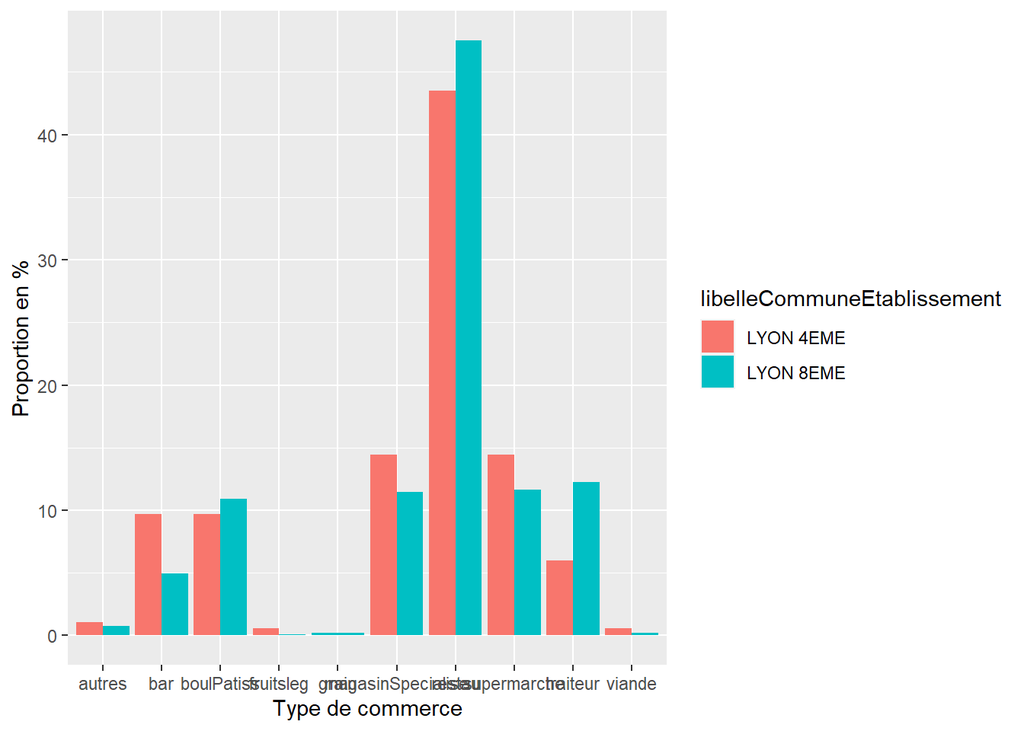

```r
#TEST print(filter(alimRA_typeCom,libelleCommuneEtablissement=="LYON 4EME" | libelleCommuneEtablissement=="LYON 3EME" ))

ggplot(data=filter(alimRA_typeCom,libelleCommuneEtablissement=="LYON 4EME" | libelleCommuneEtablissement=="LYON 8EME" ), aes(x=TypeAbreg, y=propInTypeCom*100, fill=libelleCommuneEtablissement)) +
geom_bar(stat="identity", position=position_dodge())+labs(x="Type de commerce", y="Proportion en %")
```

```r
#+  scale_x_discrete(labels = abbreviate)
```

## 3.5 Evolution dans le temps des créations d’entreprise

# 3.5.1 Manipuler des dates avec lubridate

- Installez et chargez le package lubridate.
- Transformez le tableau alimRA_entr en modifiant la classe de dateCreationEtablissement à l’aide d’une fonction de lubridate.
- Ajoutez une variable annee au tableau alimRA_entr à l’aide, à nouveau, d’une des fonctions de lubridate.

```r
print(paste("type de dateCreationEtablissement : ",class(alimRA_entr$dateCreationEtablissement),sep = "", collapse = NULL))
```

```
## [1] "type de dateCreationEtablissement : character"
```

```r
alimRA_entr$dateCreationEtablissement=ymd(alimRA_entr$dateCreationEtablissement)
print(paste("type de dateCreationEtablissement après ymd() : ",class(alimRA_entr$dateCreationEtablissement),sep = "", collapse = NULL))
```

```
## [1] "type de dateCreationEtablissement après ymd() : Date"
```

```r
alimRA_entr$annee=year(alimRA_entr$dateCreationEtablissement)
alimRA_entr=arrange(alimRA_entr,desc(enseigne1Etablissement))
# test:
print(head(paste( alimRA_entr$enseigne1Etablissement," SINCE ",alimRA_entr$annee,sep = "", collapse = NULL)))
```

```
## [1] "ZUMO SINCE 2009"               "ZUMO SINCE 2009"
## [3] "ZSB - EXPRESS FOOD SINCE 2010" "ZOZO SINCE 2012"
## [5] "ZOOZ SINCE 2015"               "ZOOM SINCE 2007"
```

# 3.5.2 Résumé, filtre

- Créez une table alimRA_typeAn qui recense le **nombre d’entreprises par année (nInAn), et par type*année (nInTypeAn)**.
- Filtrez les données de alimRA_typeAn pour ne garder que les entreprises dont la création correspond aux années >=1970.

```r
alimRA_typeAn=left_join(summarise(group_by(alimRA_entr,annee,TypeAbreg),nInTypeAn=n()),summarise(group_by(alimRA_entr,annee),nInAn=n()),by = c("annee" = "annee"))

alimRA_typeAn=filter(alimRA_typeAn,annee>=1970 & annee<2020)
head(alimRA_typeAn)
```

```
## # A tibble: 6 x 4
## # Groups:   annee [1]
##   annee TypeAbreg         nInTypeAn nInAn
##   <dbl> <chr>                 <int> <int>
## 1  1970 bar                       8    20
## 2  1970 boulPatiss                3    20
## 3  1970 magasinSpecialise         1    20
## 4  1970 restau                    4    20
## 5  1970 supermarche               3    20
## 6  1970 viande                    1    20
```

# 3.5.3 Graphiques: évolution du nombre d’entreprises au cours du temps

- Installez et chargez le package ggplot2
- Réalisez un graphique représentant l’évolution des proportions d’entreprises (par type) par année.
- Réalisez ce même graphique, mais en représentant le nombre de créations d’entreprises par année et par type, pour les 5 types comptant le plus de créations d’entreprises (au total).

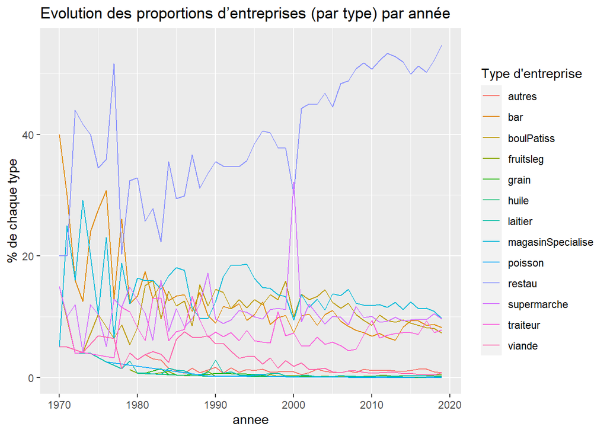

```r
ggplot(alimRA_typeAn, aes(x=annee, y=nInTypeAn/nInAn*100, color=TypeAbreg))+
  geom_line() +labs(y="% de chaque type",title="Evolution des proportions d’entreprises (par type) par année",color="Type d'entreprise")
```

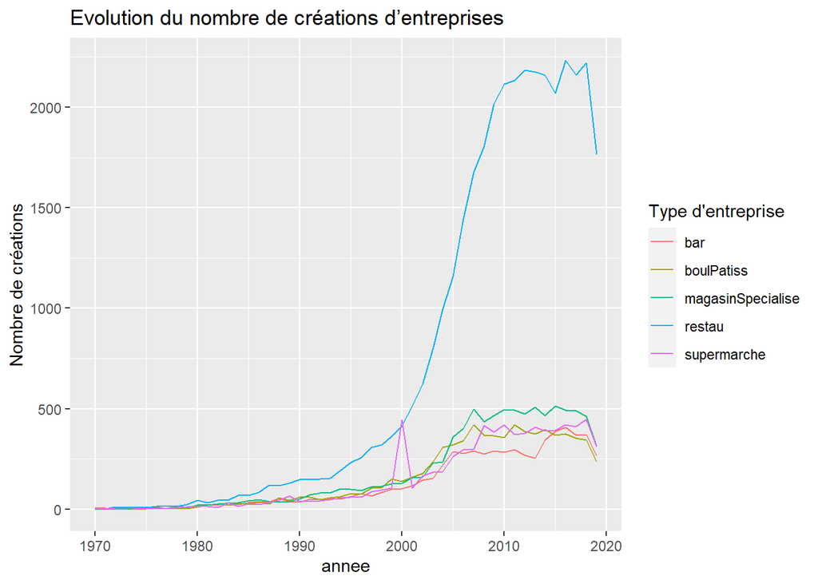

```r
ggplot(filter(alimRA_typeAn, TypeAbreg %in% head(arrange(summarise(group_by(alimRA_typeAn,TypeAbreg),sumInTypeAn=sum(nInTypeAn)),desc(sumInTypeAn)),5)$TypeAbreg), aes(x=annee, y=nInTypeAn, color=TypeAbreg)) +
  geom_line() +labs(y="Nombre de créations",title="Evolution du nombre de créations d’entreprises",color="Type d'entreprise")
```

## 3.6 Cartes

# 3.6.1 Carte des boulangeries-pâtisseries

- Repartez de la table alim_entr pour en faire un objet de classe “sf”. Vous vous servirez pour cela des colonnes “longitude” et “latitude” et exclurez les entreprises pour lesquelles ces colonnes ne sont pas renseignées.
- Réalisez une carte montrant le semis de points correspondant aux boulangeries-pâtisseries.
- Essayez de représenter à travers cette carte l’année de création de l’entreprise (de la manière qui vous semblera la plus pertinente).

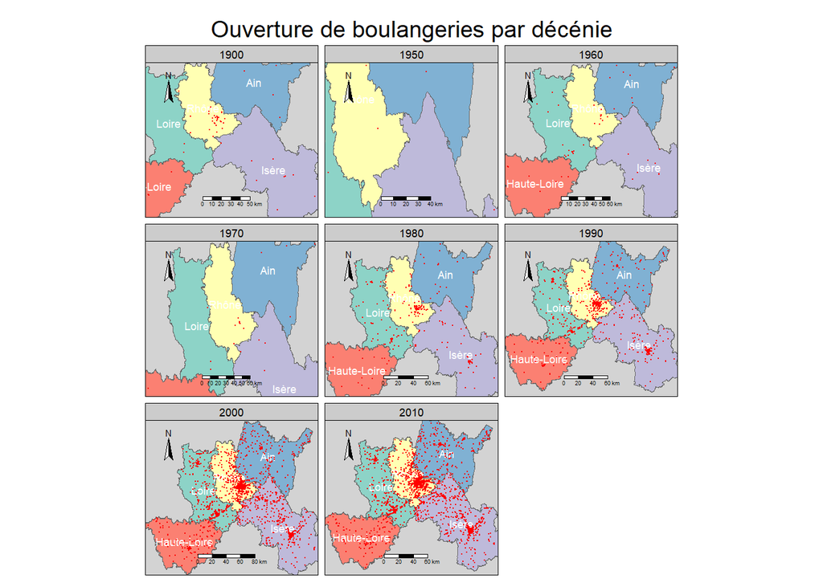

```r
# tuto tmap: https://cran.r-project.org/web/packages/tmap/vignettes/tmap-getstarted.html

############## recuperation des positions des boulangeries-pâtisseries ##############

points = st_as_sf(filter(select(alimRA_entr,longitude,latitude,dateCreationEtablissement,TypeAbreg), !is.na(longitude) & !is.na(latitude) & latitude>40 & TypeAbreg=="boulPatiss") , coords = c("longitude", "latitude"), crs = 4326, agr = "constant")

#ajout de la decenie de creation
points=mutate(points, decenieCreationEtablissement=floor(year(ymd(dateCreationEtablissement))/10)*10)


############## recuperation des départements avec webservice ##############

#lien vers le service WFS
wfs <- "https://datacarto.datara.gouv.fr/wfs/6ef4743b-1ec7-4615-a1a7-d7a7bbfd8b42"

# connexion au service
client <- WFSClient$new(wfs,serviceVersion = "2.0.0")

# recuperation des possibilité du serveur
caps= client$getCapabilities()

# Liste des couches "featuretype" disponibles
featuretype= caps$getFeatureTypes()

# recupération de la couche departement (ici la seule dispo)
departement= featuretype[[1]]$getFeatures()

# recuperation des départements concernés, données légères : on peut filtrer après le telechargement
departement=filter(departement, insee_dep %in% c('01','38','42','43','69'))


#TEST : une autre manière de recuperer une couche en WFS
#
#test <- wfs %>%
#  parse_url() %>%
#  list_merge(query = list(service = "wfs",
#                          version = "2.0.0",
#                          request = "GetFeature",
#                          typeName = "departement_adminexp_s_r84",
#                          cql_filter="insee_dep = 01"
#                          )) %>%
#  build_url() %>%
#  read_sf()



# pour des cartes statiques
tmap_mode("plot")
# TEST: tmap_mode("view") pour des cartes interactives


##############  creation de la carte   #################

# cartes trop petites mais je voulais essayer les facets

tm_shape(departement)+
  tm_polygons("nom_dep",legend.show = FALSE)+
  tm_text("nom_dep", size = 1, col="white")+
  tm_legend(show = FALSE)+
tm_shape(points)+
  # une carte par décénie
  tm_facets(by="decenieCreationEtablissement")+
  tm_dots(col="red") +
  tm_layout(main.title="Ouverture de boulangeries par décénie", main.title.size = 1.2 , main.title.position = "center", bg.color = "lightgrey", inner.margins = c(.05, .02, .02, .02))+
  tm_scale_bar(position=c("center", "bottom"))+
  tm_compass(position=c("left", "top"))
```

# 3.6.2 Carte des proportions de commerce par commune

- Téléchargez le shapefile des limites de communes en France ici et filtrez pour ne garder que les départements considérés ci-dessus.
- Joignez aux communes les informations concernant les commerces (st_join()…) et calculez le nombre de commerces par commune.
- Produisez une carte montrant le nombre de commerces par commune. Vous aurez sans doute à retravailler l’échelle colorée…

```r
###############" recuperation des communes de ARA avec webservice #####################


# TEST: ouvertue des commune en shapefile
#communes=st_read(paste0("data/","com.shp")) %>%  st_set_crs(2154)
#communes = st_transform(communes, st_crs(4326))



#lien vers le service WFS
wfs <- "https://wxs.ign.fr/beta/geoportail/wfs"

# recuperation des données en json avec filtre car les données sont lourdes
r = GET("https://wxs.ign.fr/beta/geoportail/wfs",
  query = list(service = "wfs",
               version = "2.0.0",
               request = "GetFeature",
               typeName = "CADASTRALPARCELS.PARCELLAIRE_EXPRESS:commune",
               outputFormat="application/json",
               CQL_FILTER="code_dep IN ('01', '38')"
               ))

# conversion en simple features
communes=read_sf(r)

# Rhaaa! téléchargement en plusieurs fois car le serveur limite à 1000 features
r = GET("https://wxs.ign.fr/beta/geoportail/wfs",
  query = list(service = "wfs",
               version = "2.0.0",
               request = "GetFeature",
               typeName = "CADASTRALPARCELS.PARCELLAIRE_EXPRESS:commune",
               outputFormat="application/json",
               CQL_FILTER="code_dep IN ('42', '43','69')"
               ))

# regroupement des 2 objet sf
communes=rbind(communes,read_sf(r))

commerces = st_as_sf(filter(select(alimRA_entr,longitude,latitude,siren),!is.na(longitude) & !is.na(latitude)), coords = c("longitude", "latitude"), crs = 4326, agr = "constant")

# solve the problem: "invalid spherical geometry"
sf::sf_use_s2(FALSE)
```

```
## Spherical geometry (s2) switched off
```

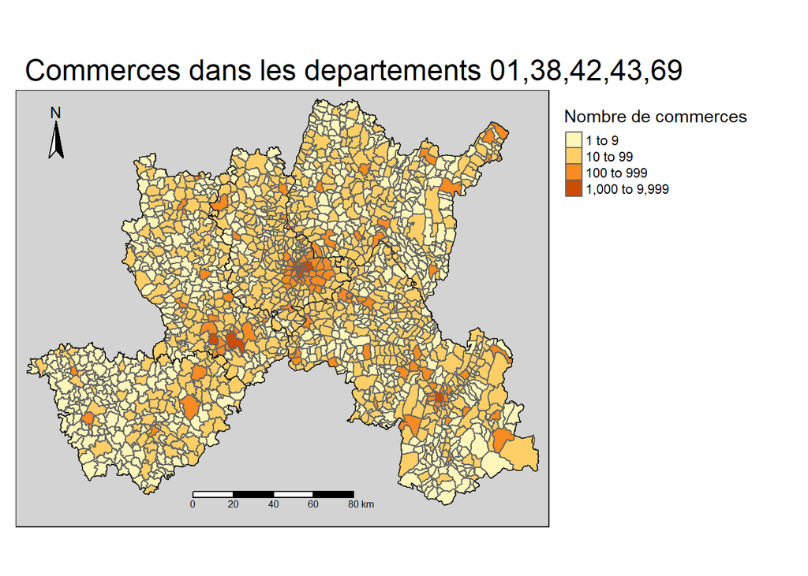

```r
# spatial join for each commune
final=summarise(group_by(st_join(communes,commerces),nom_com),n_commerce=n())

# create map, choix d'une legende en log10 car les ecarts sont tres importants
tm_shape(final)+
  tm_polygons(col="n_commerce",style = "log10_pretty", title="Nombre de commerces") +
  tm_layout(legend.outside = TRUE, main.title="Commerces dans les departements 01,38,42,43,69", main.title.size=1.5,main.title.position="left", bg.color = "lightgrey", inner.margins = c(.05, .02, .02, .02))+
tm_shape(departement)+
  tm_borders("black", lwd = .7)+
  tm_scale_bar(position="center")+
  tm_compass(position=c("left","top"))
```